# Project 2 Linear Regression

Brandtly Jones

2022-08-09

```r
#import data
library(tidyverse)
```

```r
library(corrplot)
data<-as_tibble(read.csv("~/MSDS/STAT6021/Project2/kc_house_data.csv"))
```

#### Define categorical variables

Change waterfront to categorical.

```r
data$waterfront <- factor(data$waterfront)
levels(data$waterfront) <- c("no","yes")
```

Change view to categorical.

```r
data$view <- factor(data$view)
levels(data$view) <- c("no", "yes", "yes", "yes", "yes")
```

#### Create new variables

Create categorical variable ‘renovated’ for houses showing a renovation:

```r
data <- data %>% mutate(renovated = yr_renovated>0)
data$renovated<-factor(data$renovated)
levels(data$renovated)<- c("no","yes")
```

Create variable age from (2015-yr_built) to age.

```r
data <- mutate(data, age = 2015 - yr_built)
```

Create variable since_reno. This is the the “age” of the house since its last renovation. For houses without renovations, the value is identical to “age”, for those with renovations, the “age” of the house is reset to the time since the renovation:

```r
data<-data %>% mutate(since_reno = ifelse(renovated=='no', age, 2015-yr_renovated ))
```

Create categorical variable over_budget for our hypothetical Seattle transplant finding a home for ($718,000).

```r
data <- data %>% mutate(over_budget = price > 718000)
data$over_budget <- factor(data$over_budget)
levels(data$over_budget) <- c("no","yes")
```

Change sqft_basement to basement.

```r
data <- data %>% mutate(has_basement = sqft_basement>0)
data$has_basement <- factor(data$has_basement)
levels(data$has_basement) <- c("no","yes")
```

Change date to season.

```r
data$date <- substr(data$date,start=1,stop=8)
data$year <- substr(data$date,start=1,stop=4)
data$month <- substr(data$date, start=5, stop=6)
data$day <- substr(data$date, start=7, stop=8)
data$season <- ifelse(data$month=="05"|
                       data$month=="06"|
                       data$month=="07"|
                       data$month=="08"|
                       data$month=="09","summer","non-summer")
```

So what are we working with?

```r
names(data)
```

```
##  [1] "id"            "date"          "price"         "bedrooms"
##  [5] "bathrooms"     "sqft_living"   "sqft_lot"      "floors"
##  [9] "waterfront"    "view"          "condition"     "grade"
## [13] "sqft_above"    "sqft_basement" "yr_built"      "yr_renovated"
## [17] "zipcode"       "lat"           "long"          "sqft_living15"
## [21] "sqft_lot15"    "renovated"     "age"           "since_reno"
## [25] "over_budget"   "has_basement"  "year"          "month"
## [29] "day"           "season"
```

House id and zipcode are not going into the model so we’ll delete them.

```r
data<-data %>% select(-id, -zipcode)
```

Let’s have a look at our quatitative variables to find correlations:

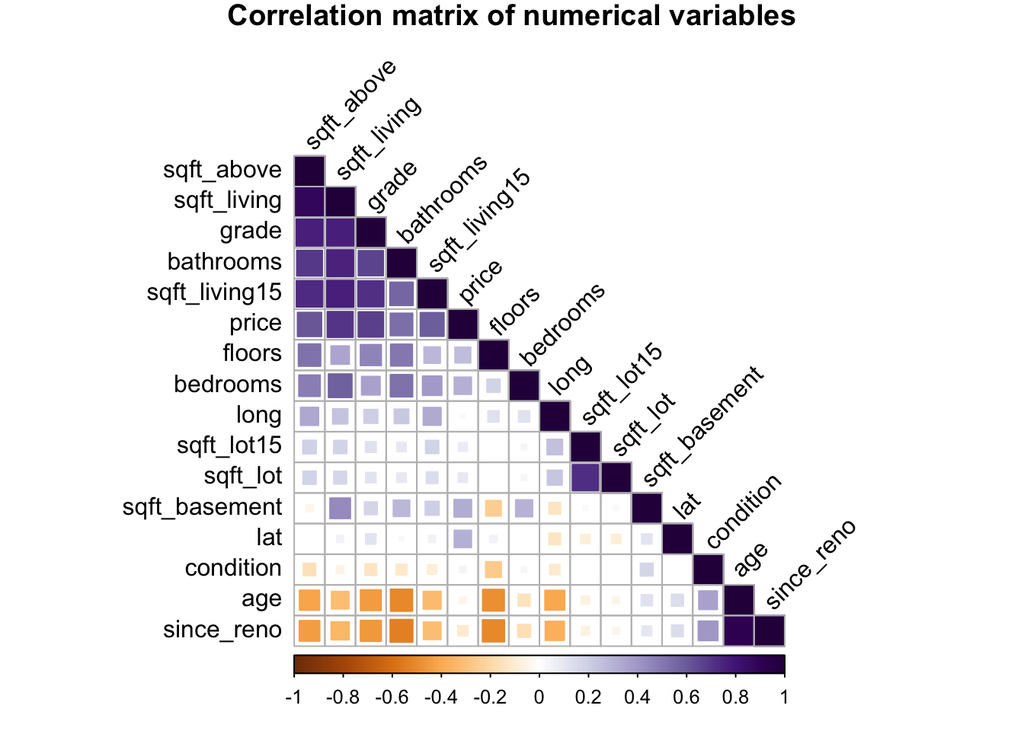

```r
quant_cor <- data %>%
  select(price, bedrooms, bathrooms, sqft_living, sqft_above, sqft_lot, floors,
                       condition, grade, sqft_basement, lat, long, sqft_living15,
                       sqft_lot15, age, since_reno) %>%
  cor(use = 'complete.obs') %>%
  round(2)

corrplot(quant_cor, type = "lower", order = "FPC", diag = T, method = 'square',
         col = COL2('PuOr'),
         tl.col = "black", tl.srt = 45,
         title = "Correlation matrix of numerical variables",
         mar=c(0,0,1,0))
```

For better or worse, we see strong negative correlations with a number of variables like square footage, bathrooms, and floors. Somewhat surprisingly there is a positive correlation between age and condition.

before proceding, we will split our data into a training and test set with an 80/20 split:

```r
set.seed(206)
samp<-sample.int(nrow(data), floor(.80*nrow(data)), replace = F)
train<-data[samp, ] ##training data frame
test<-data[-samp, ] ##test data frame
```

We will now try some automated search procedures to fit a linear regression model with our features. We obviously cannot include data which contains the age of the house like yr_built, or since_reno (which is mostly identical to age), and yr_renovated is a bit of a cheat since this gives a terminus ante quem for the age of the house. So our slightly reduced data set is regdata:

```r
regdata<-train %>% select(-yr_built, -since_reno, -year, -month, -day, -yr_renovated)
```

```r
##intercept only model
regnull <- lm(age~1, data=regdata)
##model with all predictors
regfull <- lm(age~., data=regdata)
```

We will attempt a step-wise search of the models from the intercept-only model through the full training regdata.

```r
step(regnull, scope=list(lower=regnull, upper=regfull), direction="both")
```

```
## Start:  AIC=116906.9
## age ~ 1
##
##                  Df Sum of Sq      RSS    AIC
## + bathrooms       1   3792821 11143420 111844
## + floors          1   3550420 11385821 112216
## + grade           1   3004641 11931600 113026
## + sqft_above      1   2683748 12252493 113484
## + long            1   2529215 12407026 113701
## + condition       1   1965676 12970565 114469
## + sqft_living15   1   1570963 13365278 114987
## + sqft_living     1   1503591 13432650 115074
## + renovated       1    772284 14163957 115991
## + has_basement    1    395927 14540314 116444
## + bedrooms        1    334602 14601639 116517
## + lat             1    326496 14609745 116527
## + sqft_basement   1    256024 14680217 116610
## + sqft_lot15      1     75701 14860541 116821
## + view            1     56803 14879438 116843
## + sqft_lot        1     43739 14892502 116858
## + price           1     41550 14894691 116861
## + over_budget     1     34003 14902238 116870
## + waterfront      1      9076 14927165 116898
## <none>                        14936241 116907
## + season          1       176 14936065 116909
## + date          369    369893 14566348 117211
##
## Step:  AIC=111844
## age ~ bathrooms
##
##                  Df Sum of Sq      RSS    AIC
## + long            1   1396866  9746554 109530
## + condition       1   1374264  9769156 109570
## + sqft_basement   1   1247848  9895572 109793
## + floors          1   1107393 10036026 110036
## + renovated       1    960714 10182705 110287
## + has_basement    1    934127 10209293 110332
## + price           1    915308 10228112 110364
## + over_budget     1    498375 10645045 111055
## + lat             1    385242 10758178 111238
```

[output cut: 416 more lines]

```
## - has_basement    1      5641 5868870 100786
## - sqft_lot        1     10363 5873592 100800
## - waterfront      1     16210 5879438 100817
## - view            1     22883 5886112 100837
## - over_budget     1     35489 5898717 100874
## - bedrooms        1     44714 5907943 100901
## - lat             1     83311 5946540 101013
## + date          369    139349 5723879 101093
## - price           1    191602 6054830 101325
## - floors          1    256827 6120055 101510
## - condition       1    511055 6374283 102214
## - renovated       1    574875 6438103 102386
## - grade           1    583493 6446722 102410
## - long            1    601467 6464696 102458
## - bathrooms       1    762042 6625271 102882
```

```
##
## Call:
## lm(formula = age ~ bathrooms + long + condition + renovated +
##     floors + price + grade + bedrooms + lat + sqft_living + over_budget +
##     view + waterfront + sqft_lot + has_basement + sqft_above,
##     data = regdata)
##
## Coefficients:
##     (Intercept)        bathrooms             long        condition
##      -6.595e+03       -1.493e+01       -4.790e+01        8.979e+00
##    renovatedyes           floors            price            grade
##       2.917e+01       -9.808e+00        1.756e-05       -8.936e+00
##        bedrooms              lat      sqft_living   over_budgetyes
##       2.204e+00        1.769e+01        1.693e-03        5.430e+00
##         viewyes    waterfrontyes         sqft_lot  has_basementyes
##       4.360e+00       -1.208e+01        2.000e-05        2.189e+00
##      sqft_above
##       2.265e-03
```

So our search outputs a big-honking model with 16 predictors. We will inspect the model and see what features seem valuable and which we may want to eliminate.

```r
starting_model<-lm(age ~ bathrooms + long + condition + renovated +
    floors + price + grade + bedrooms + lat + sqft_living + over_budget +
    view + waterfront + sqft_lot + has_basement + sqft_above,
    data = regdata)
summary(starting_model)
```

```
##
## Call:
## lm(formula = age ~ bathrooms + long + condition + renovated +
##     floors + price + grade + bedrooms + lat + sqft_living + over_budget +
##     view + waterfront + sqft_lot + has_basement + sqft_above,
##     data = regdata)
##
## Residuals:
##     Min      1Q  Median      3Q     Max
## -83.154 -12.090  -1.726   9.300  81.470
##
## Coefficients:
##                   Estimate Std. Error t value Pr(>|t|)
## (Intercept)     -6.595e+03  1.476e+02 -44.676  < 2e-16 ***
## bathrooms       -1.493e+01  3.150e-01 -47.381  < 2e-16 ***
## long            -4.790e+01  1.138e+00 -42.094  < 2e-16 ***
## condition        8.979e+00  2.314e-01  38.802  < 2e-16 ***
## renovatedyes     2.917e+01  7.089e-01  41.153  < 2e-16 ***
## floors          -9.808e+00  3.566e-01 -27.507  < 2e-16 ***
## price            1.756e-05  7.390e-07  23.758  < 2e-16 ***
## grade           -8.936e+00  2.155e-01 -41.460  < 2e-16 ***
## bedrooms         2.204e+00  1.920e-01  11.477  < 2e-16 ***
## lat              1.769e+01  1.129e+00  15.666  < 2e-16 ***
## sqft_living      1.693e-03  6.318e-04   2.679  0.00739 **
## over_budgetyes   5.430e+00  5.310e-01  10.225  < 2e-16 ***
## viewyes          4.360e+00  5.310e-01   8.211 2.35e-16 ***
## waterfrontyes   -1.208e+01  1.748e+00  -6.910 5.00e-12 ***
## sqft_lot         2.000e-05  3.619e-06   5.525 3.34e-08 ***
## has_basementyes  2.189e+00  5.369e-01   4.077 4.59e-05 ***
## sqft_above       2.265e-03  6.924e-04   3.272  0.00107 **
## ---
## Signif. codes:  0 '***' 0.001 '**' 0.01 '*' 0.05 '.' 0.1 ' ' 1
##
## Residual standard error: 18.42 on 17273 degrees of freedom
## Multiple R-squared:  0.6074, Adjusted R-squared:  0.6071
## F-statistic:  1671 on 16 and 17273 DF,  p-value: < 2.2e-16
```

Our p-value suggests our model is useful for predicting the response. Moreover, the model indicates that all of these features are significant in the presence of the rest. sqft_living and sqft_above are shown as slightly less significant. Indeed the pair have a 0.875 correlation.

```r
cor(regdata$sqft_above, regdata$sqft_living, method='pearson')
```

```
## [1] 0.8753966
```

Before deciding what features, if any, we want to drop, we will do the usual tests of the assumptions for linear models.

```r
library(faraway)
vif(starting_model)
```

```
##       bathrooms            long       condition    renovatedyes          floors
##        3.000672        1.310722        1.149102        1.048574        1.884248
##           price           grade        bedrooms             lat     sqft_living
##        3.760243        3.300919        1.640062        1.252203       17.209738
##  over_budgetyes         viewyes   waterfrontyes        sqft_lot has_basementyes
##        2.209502        1.280834        1.170451        1.100879        3.500108
##      sqft_above
##       16.665129
```

As expected, sqft_living and sqft_above have high VIF scores due to their close correlation.

Let’s check our residuals:

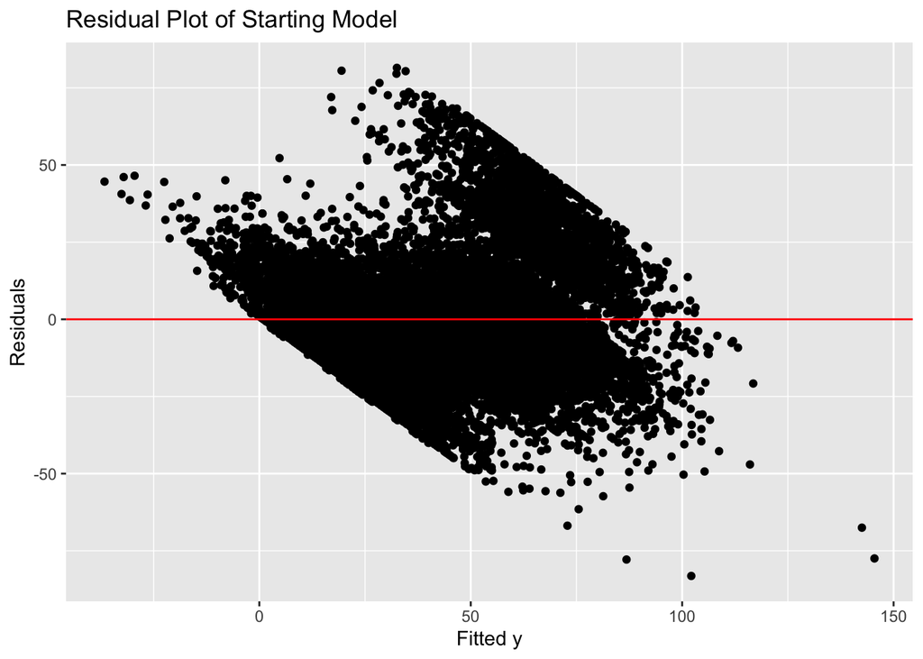

```r
yhat<-starting_model$fitted.values
res<-starting_model$residuals
Data<-data.frame(regdata, yhat, res)
##residual plot
ggplot(Data, aes(x=yhat,y=res))+
geom_point()+
geom_hline(yintercept=0, color="red")+
labs(x="Fitted y", y="Residuals", title="Residual Plot of Starting Model")
```

That is definitely not a nice even spread. The residuals appear biased. The results are showing a linear pattern which could be due to a lurking variable not in the data.

Checking the ACF:

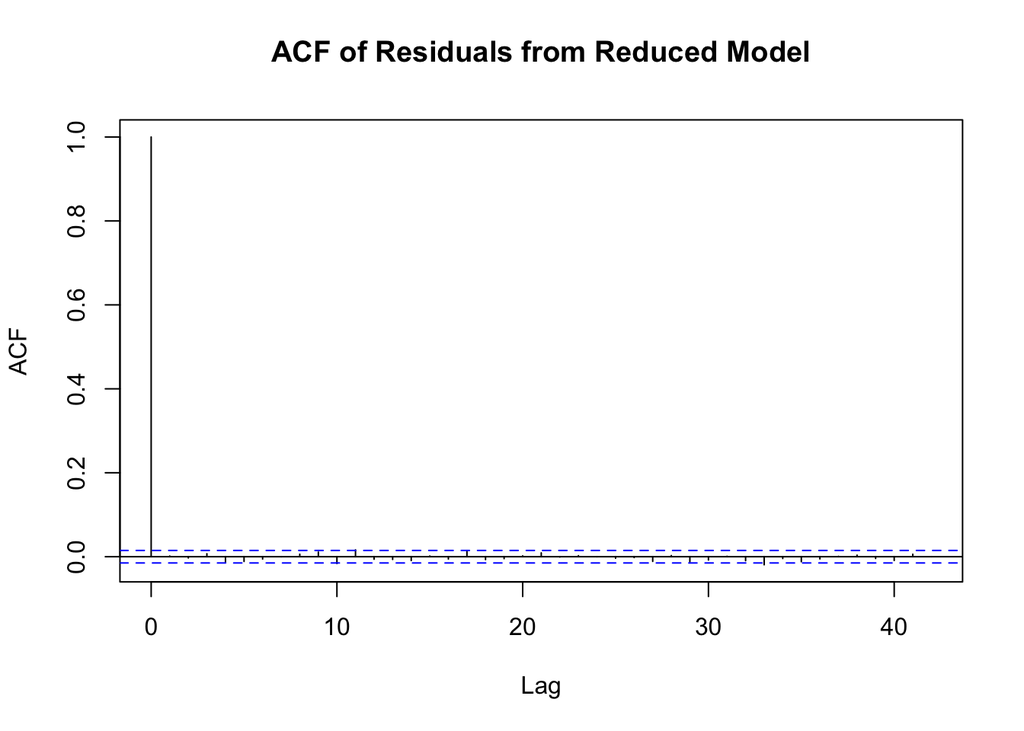

```r
acf(res, main="ACF of Residuals from Reduced Model")
```

The ACF plot does show a few points which go beyond the bounds of significance.

Finally a QQ plot. Based on our residual plot, we don’t expect a nice normal distribution:

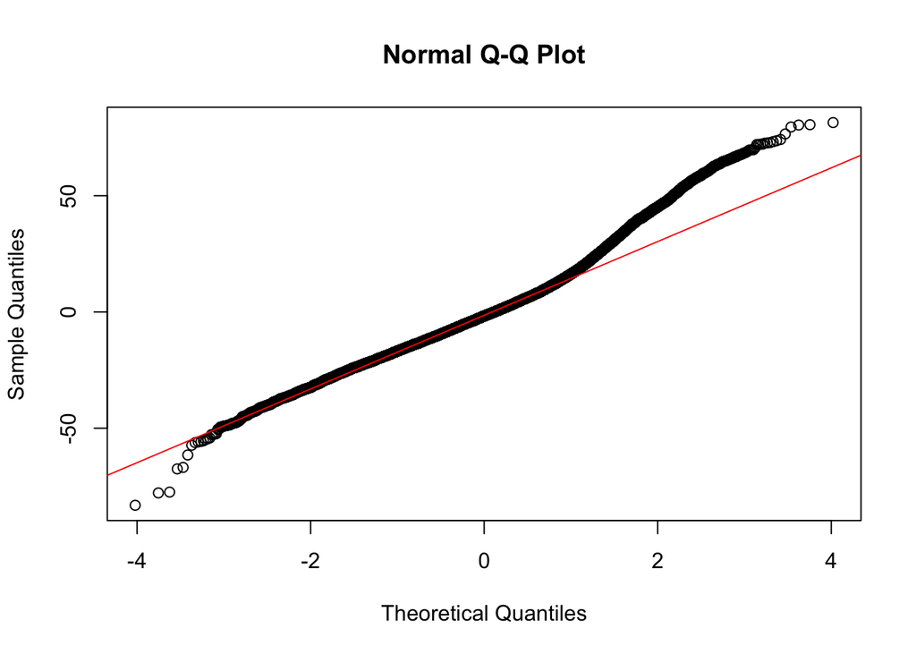

```r
qqnorm(res)
qqline(res, col="red")
```

Our sample quantiles veer far off, indicating some right-skew and fat tails.

It’s not clear how we should transform our data to better meet the assumptions of linear aggression. We can try eliminating some variables, however, and see if we can get a better model with fewer features.

A reminder our starting model was: formula = age ~ bathrooms + long + condition + renovated + floors + price + grade + bedrooms + lat + sqft_living + over_budget + view + waterfront + sqft_lot + has_basement + sqft_above

We will eliminate sqft_above, as it interferes with sqft_living. Also, over_budget is contained in price.

So our reduced model is: formula = age ~ bathrooms + long + condition + renovated + floors + price + grade + bedrooms + lat + sqft_living + view + waterfront + sqft_lot + has_basement

```r
reduced<-lm(age ~ bathrooms + long + condition + renovated +
    floors + price + grade + bedrooms + lat + sqft_living +
    view + waterfront + sqft_lot + has_basement, data=regdata)
summary(reduced)
```

```
##
## Call:
## lm(formula = age ~ bathrooms + long + condition + renovated +
##     floors + price + grade + bedrooms + lat + sqft_living + view +
##     waterfront + sqft_lot + has_basement, data = regdata)
##
## Residuals:
##     Min      1Q  Median      3Q     Max
## -85.928 -12.016  -1.821   9.191  81.167
##
## Coefficients:
##                   Estimate Std. Error t value Pr(>|t|)
## (Intercept)     -6.617e+03  1.475e+02 -44.871  < 2e-16 ***
## bathrooms       -1.511e+01  3.156e-01 -47.887  < 2e-16 ***
## long            -4.799e+01  1.138e+00 -42.178  < 2e-16 ***
## condition        9.025e+00  2.308e-01  39.096  < 2e-16 ***
## renovatedyes     2.954e+01  7.099e-01  41.610  < 2e-16 ***
## floors          -9.488e+00  3.445e-01 -27.544  < 2e-16 ***
## price            2.075e-05  6.743e-07  30.775  < 2e-16 ***
## grade           -8.510e+00  2.109e-01 -40.351  < 2e-16 ***
## bedrooms         2.237e+00  1.926e-01  11.613  < 2e-16 ***
## lat              1.782e+01  1.132e+00  15.751  < 2e-16 ***
## sqft_living      3.703e-03  3.412e-04  10.853  < 2e-16 ***
## viewyes          4.543e+00  5.283e-01   8.600  < 2e-16 ***
## waterfrontyes   -1.357e+01  1.749e+00  -7.762 8.81e-15 ***
## sqft_lot         2.045e-05  3.628e-06   5.637 1.76e-08 ***
## has_basementyes  6.958e-01  3.444e-01   2.020   0.0434 *
## ---
## Signif. codes:  0 '***' 0.001 '**' 0.01 '*' 0.05 '.' 0.1 ' ' 1
##
## Residual standard error: 18.49 on 17275 degrees of freedom
## Multiple R-squared:  0.6048, Adjusted R-squared:  0.6044
## F-statistic:  1888 on 14 and 17275 DF,  p-value: < 2.2e-16
```

This model is likewise significant by its p-value, though now has_basement is less significant in the presence of the other predictors. We can do a partial F test between the full and reduced models.

```r
anova(reduced, starting_model)
```

```
## Analysis of Variance Table
##
## Model 1: age ~ bathrooms + long + condition + renovated + floors + price +
##     grade + bedrooms + lat + sqft_living + view + waterfront +
##     sqft_lot + has_basement
## Model 2: age ~ bathrooms + long + condition + renovated + floors + price +
##     grade + bedrooms + lat + sqft_living + over_budget + view +
##     waterfront + sqft_lot + has_basement + sqft_above
##   Res.Df     RSS Df Sum of Sq      F    Pr(>F)
## 1  17275 5903353
## 2  17273 5863228  2     40125 59.104 < 2.2e-16 ***
## ---
## Signif. codes:  0 '***' 0.001 '**' 0.01 '*' 0.05 '.' 0.1 ' ' 1
```

We get a significant result, indicating that the coefficients for one of the predictors dropped (over_budget and sqft_above) is non-zero and we should go with the full model.

We can try adding over_budget back in as it was highly significant in the full model, and we can drop has_basement since it was less significant in the first reduced model:

```r
starting_model_exp<-lm(exp(age) ~ bathrooms + long + condition + renovated +
    floors + price + grade + bedrooms + lat + sqft_living + over_budget +
    view + waterfront + sqft_lot + has_basement + sqft_above,
    data = regdata)
summary(starting_model_exp)
```

```
##
## Call:
## lm(formula = exp(age) ~ bathrooms + long + condition + renovated +
##     floors + price + grade + bedrooms + lat + sqft_living + over_budget +
##     view + waterfront + sqft_lot + has_basement + sqft_above,
##     data = regdata)
##
## Residuals:
##        Min         1Q     Median         3Q        Max
## -6.639e+48 -7.369e+47 -3.654e+47 -8.690e+45  8.780e+49
##
## Coefficients:
##                   Estimate Std. Error t value Pr(>|t|)
## (Intercept)     -1.460e+50  4.556e+49  -3.205 0.001353 **
## bathrooms       -3.189e+47  9.723e+46  -3.280 0.001040 **
## long            -1.111e+48  3.512e+47  -3.164 0.001560 **
## condition       -4.756e+46  7.142e+46  -0.666 0.505493
## renovatedyes     1.424e+48  2.188e+47   6.511 7.67e-11 ***
## floors           4.162e+47  1.100e+47   3.782 0.000156 ***
## price            9.388e+41  2.281e+41   4.116 3.87e-05 ***
## grade           -4.566e+47  6.652e+46  -6.864 6.92e-12 ***
## bedrooms         2.044e+47  5.926e+46   3.449 0.000564 ***
## lat              2.780e+47  3.484e+47   0.798 0.425000
## sqft_living      9.104e+42  1.950e+44   0.047 0.962763
## over_budgetyes   3.471e+47  1.639e+47   2.118 0.034221 *
## viewyes          9.988e+46  1.639e+47   0.609 0.542250
## waterfrontyes   -1.423e+48  5.395e+47  -2.637 0.008363 **
## sqft_lot         5.623e+41  1.117e+42   0.503 0.614701
## has_basementyes -2.407e+47  1.657e+47  -1.453 0.146273
## sqft_above      -5.530e+43  2.137e+44  -0.259 0.795813
## ---
## Signif. codes:  0 '***' 0.001 '**' 0.01 '*' 0.05 '.' 0.1 ' ' 1
##
## Residual standard error: 5.686e+48 on 17273 degrees of freedom
## Multiple R-squared:  0.01185,    Adjusted R-squared:  0.01093
## F-statistic: 12.95 on 16 and 17273 DF,  p-value: < 2.2e-16
```

```r
reduced2<- lm(age ~ bathrooms + long + condition + renovated +
   over_budget + floors + price + grade + bedrooms + lat + sqft_living +
   view + waterfront + sqft_lot,  data=regdata)
summary(reduced2)
```

```
##
## Call:
## lm(formula = age ~ bathrooms + long + condition + renovated +
##     over_budget + floors + price + grade + bedrooms + lat + sqft_living +
##     view + waterfront + sqft_lot, data = regdata)
##
## Residuals:
##     Min      1Q  Median      3Q     Max
## -83.595 -12.136  -1.708   9.260  82.046
##
## Coefficients:
##                  Estimate Std. Error t value Pr(>|t|)
## (Intercept)    -6.667e+03  1.398e+02 -47.680  < 2e-16 ***
## bathrooms      -1.479e+01  3.083e-01 -47.963  < 2e-16 ***
## long           -4.838e+01  1.091e+00 -44.351  < 2e-16 ***
## condition       8.930e+00  2.302e-01  38.783  < 2e-16 ***
## renovatedyes    2.911e+01  7.090e-01  41.061  < 2e-16 ***
## over_budgetyes  5.449e+00  5.304e-01  10.274  < 2e-16 ***
## floors         -9.797e+00  3.201e-01 -30.609  < 2e-16 ***
## price           1.753e-05  7.392e-07  23.711  < 2e-16 ***
## grade          -8.854e+00  2.116e-01 -41.838  < 2e-16 ***
## bedrooms        2.197e+00  1.921e-01  11.437  < 2e-16 ***
## lat             1.795e+01  1.117e+00  16.073  < 2e-16 ***
## sqft_living     3.569e-03  3.366e-04  10.601  < 2e-16 ***
## viewyes         4.310e+00  5.248e-01   8.212 2.33e-16 ***
## waterfrontyes  -1.227e+01  1.748e+00  -7.022 2.28e-12 ***
## sqft_lot        2.019e-05  3.615e-06   5.585 2.37e-08 ***
## ---
## Signif. codes:  0 '***' 0.001 '**' 0.01 '*' 0.05 '.' 0.1 ' ' 1
##
## Residual standard error: 18.43 on 17275 degrees of freedom
## Multiple R-squared:  0.6071, Adjusted R-squared:  0.6068
## F-statistic:  1906 on 14 and 17275 DF,  p-value: < 2.2e-16
```

```r
anova(reduced2, starting_model)
```

```
## Analysis of Variance Table
##
## Model 1: age ~ bathrooms + long + condition + renovated + over_budget +
##     floors + price + grade + bedrooms + lat + sqft_living + view +
##     waterfront + sqft_lot
## Model 2: age ~ bathrooms + long + condition + renovated + floors + price +
##     grade + bedrooms + lat + sqft_living + over_budget + view +
##     waterfront + sqft_lot + has_basement + sqft_above
##   Res.Df     RSS Df Sum of Sq      F    Pr(>F)
## 1  17275 5868886
## 2  17273 5863228  2    5657.3 8.3332 0.0002414 ***
## ---
## Signif. codes:  0 '***' 0.001 '**' 0.01 '*' 0.05 '.' 0.1 ' ' 1
```

Even with the collinearity, our anova test indicates that we have non-zero coefficients for our dropped predictors and so we go with the starting model.

Now we can test it against the test set to see how we do.

How often does our model get within 5 years of the correct age?

```r
preds<-predict(starting_model, newdata = test, interval = 'confidence')

accuracy<-function(predict_vec, threshold){
  sum(abs(predict_vec[,1]-test$age)<=threshold)/dim(predict_vec)[1]}

accuracy(preds, 5)
```

```
## [1] 0.2498265
```

Not awesome predictive power.

10 years?

```r
accuracy(preds,10)
```

```
## [1] 0.4596345
```

Jumps close to 50%